# Chapter 8: Baseline Experiments

**Purpose:** Train baseline models to understand data predictability and establish performance benchmarks.

**What you'll learn:**

- How to prepare data for ML with proper train/test splitting
- How to handle class imbalance with class weights
- How to evaluate models with appropriate metrics (not just accuracy!)
- How to interpret feature importance

**Outputs:**

- Baseline model performance (AUC, Precision, Recall, F1)
- Feature importance rankings
- ROC and Precision-Recall curves
- Performance benchmarks for comparison

## Evaluation Metrics for Imbalanced Data

| Metric | What It Measures | When to Use |
| --- | --- | --- |
| **AUC-ROC** | Ranking quality across thresholds | General model comparison |
| **Precision** | "Of predicted churned, how many are correct?" | When false positives are costly |
| **Recall** | "Of actual churned, how many did we catch?" | When missing churners is costly |
| **F1-Score** | Balance of precision and recall | When both matter equally |
| **PR-AUC** | Precision-Recall under curve | Better for imbalanced data |

## 8.1 Setup

**Show/Hide Code**

```python
from customer_retention.analysis.notebook_progress import track_and_export_previous

track_and_export_previous("08_baseline_experiments.ipynb")

import pandas as pd
from sklearn.ensemble import GradientBoostingClassifier, RandomForestClassifier
from sklearn.linear_model import LogisticRegression
from sklearn.metrics import (
    average_precision_score,
    classification_report,
    f1_score,
    precision_score,
    recall_score,
    roc_auc_score,
)
from sklearn.model_selection import cross_val_score, train_test_split
from sklearn.preprocessing import LabelEncoder, StandardScaler

from customer_retention.analysis.auto_explorer import ExplorationFindings
from customer_retention.analysis.visualization import ChartBuilder, display_figure, display_table
from customer_retention.core.config.column_config import NON_FEATURE_COLUMN_TYPES, ColumnType
from customer_retention.core.config.experiments import (
    FINDINGS_DIR,
)
```

**Show/Hide Code**

```python
from pathlib import Path

from customer_retention.analysis.auto_explorer import load_notebook_findings, resolve_target_column

FINDINGS_PATH, _namespace, dataset_name = load_notebook_findings(
    "08_baseline_experiments.ipynb", prefer_aggregated=True
)
print(f"Using: {FINDINGS_PATH}")

findings = ExplorationFindings.load(FINDINGS_PATH)
target = resolve_target_column(_namespace, findings)

# Load data - prefer aggregated entity-level data for modeling
from customer_retention.analysis.auto_explorer.active_dataset_store import load_active_dataset
from customer_retention.core.config.column_config import DatasetGranularity
from customer_retention.stages.temporal import TEMPORAL_METADATA_COLS

if "_aggregated" in FINDINGS_PATH:
    source_path = Path(findings.source_path)
    if not source_path.is_absolute():
        source_path = Path("..") / source_path
    if source_path.is_dir():
        from customer_retention.integrations.adapters.factory import get_delta
        df = get_delta(force_local=True).read(str(source_path))
    elif source_path.is_file():
        df = pd.read_parquet(source_path)
    else:
        df = load_active_dataset(_namespace, dataset_name)
    data_source = f"aggregated:{source_path.name}"
elif dataset_name is None and _namespace:
    from customer_retention.integrations.adapters.factory import get_delta
    df = get_delta(force_local=True).read(str(_namespace.silver_merged_path))
    data_source = "silver_merged"
else:
    df = load_active_dataset(_namespace, dataset_name)
    data_source = dataset_name

charts = ChartBuilder()

print(f"\nLoaded {len(df):,} rows from: {data_source}")
```

```
Using: /Users/Vital/python/CustomerRetention/experiments/runs/email-6301db6c/datasets/customer_emails/findings/customer_emails_aggregated_findings.yaml
```

```
Loaded 4,998 rows from: aggregated:customer_emails_aggregated
```

## 8.2 Prepare Data for Modeling

**📖 Feature Source:**

Features used in this notebook come from the **ExplorationFindings** generated in earlier notebooks:

- Column types are **auto-detected** in notebook 01 (Data Discovery)
- Target column is identified from the findings
- Identifier columns are **excluded** to prevent data leakage
- Text columns are **excluded** (require specialized NLP processing)

**📖 Best Practices:**

1. **Stratified Split**: Maintains class ratios in train/test sets
2. **Scale After Split**: Fit scaler on train only (prevents data leakage)
3. **Handle Missing**: Impute or drop before scaling

**📖 Transformations Applied:**

- Categorical variables → Label Encoded
- Missing values → Median (numeric) or Mode (categorical)
- Features → StandardScaler (fit on train only)

**Show/Hide Code**

```python
if not target:
    raise ValueError("No target column set. Please define one in exploration notebooks.")

y = df[target]

feature_cols = [
    name for name, col in findings.columns.items()
    if col.inferred_type not in NON_FEATURE_COLUMN_TYPES
    and name not in TEMPORAL_METADATA_COLS
]

print("=" * 70)
print("FEATURE SELECTION FROM FINDINGS")
print("=" * 70)
print(f"\n  Target Column: {target}")
print(f"  Features Selected: {len(feature_cols)}")

type_counts = {}
for name in feature_cols:
    col_type = findings.columns[name].inferred_type.value
    type_counts[col_type] = type_counts.get(col_type, 0) + 1

print("\n  Features by Type:")
for col_type, count in sorted(type_counts.items()):
    print(f"   {col_type}: {count}")

excluded = [name for name, col in findings.columns.items()
            if col.inferred_type in NON_FEATURE_COLUMN_TYPES]
if excluded:
    print(f"\n  Excluded Columns ({len(excluded)}): {', '.join(excluded[:10])}{'...' if len(excluded) > 10 else ''}")
```

```
======================================================================
FEATURE SELECTION FROM FINDINGS
======================================================================

  Target Column: unsubscribed
  Features Selected: 210

  Features by Type:
   binary: 29
   categorical_nominal: 2
   numeric_continuous: 79
   numeric_discrete: 100

  Excluded Columns (7): customer_id, unsubscribed, opened_middle, clicked_middle, send_hour_middle, bounced_middle, time_to_open_hours_middle
```

**Show/Hide Code**

```python
# Check feature availability and remove problematic features
from customer_retention.stages.features.feature_selector import FeatureSelector

print("=" * 70)
print("FEATURE AVAILABILITY CHECK")
print("=" * 70)

unavailable_features = []
if findings.has_availability_issues:
    selector = FeatureSelector(target_column=target)
    availability_recs = selector.get_availability_recommendations(findings.feature_availability)
    unavailable_features = [rec.column for rec in availability_recs]

    print(f"\n⚠️  {len(availability_recs)} feature(s) have availability issues:\n")
    for rec in availability_recs:
        print(f"   • {rec.column} ({rec.issue_type}, {rec.coverage_pct:.0f}% coverage)")

    print("\n📋 Alternative approaches (for investigation):")
    print("   • segment_by_cohort: Train separate models per availability period")
    print("   • add_indicator: Create availability flags and impute missing")
    print("   • filter_window: Restrict data to feature's available period")

    original_count = len(feature_cols)
    feature_cols = [f for f in feature_cols if f not in unavailable_features]

    print(f"\n🗑️  Removed {original_count - len(feature_cols)} unavailable features")
    print(f"📊 Features remaining: {len(feature_cols)}")
else:
    print("\n✅ All features have full temporal coverage.")
```

```
======================================================================
FEATURE AVAILABILITY CHECK
======================================================================

✅ All features have full temporal coverage.
```

**Show/Hide Code**

```python
from customer_retention.analysis.auto_explorer.project_context import ProjectContext
from customer_retention.core.config.column_config import select_model_ready_columns
from customer_retention.stages.modeling import DataSplitter, SplitStrategy

_project_ctx = ProjectContext.load(_namespace.project_context_path) if _namespace and _namespace.project_context_path.exists() else None
_use_temporal = _project_ctx.intent.temporal_split if _project_ctx and _project_ctx.intent else False

X = select_model_ready_columns(df[feature_cols].copy())
feature_cols = X.columns.tolist()

_nan_target = y.isna().sum()
if _nan_target:
    _valid = y.notna()
    X, y, df = X.loc[_valid], y.loc[_valid], df.loc[_valid]
    print(f"Dropped {_nan_target} rows with missing target")

for col in X.select_dtypes(include=['object']).columns:
    le = LabelEncoder()
    X[col] = le.fit_transform(X[col].astype(str))

for col in X.columns:
    if X[col].isnull().any():
        if X[col].dtype in ['int64', 'float64']:
            X[col] = X[col].fillna(X[col].median())
        else:
            X[col] = X[col].fillna(X[col].mode()[0])

if _use_temporal and "as_of_date" in df.columns:
    _purge_gap = _project_ctx.intent.purge_gap_days if _project_ctx and _project_ctx.intent else 104
    _exclude = [c for c in ["as_of_date", "entity_id"] if c in X.columns]
    _split_df = pd.concat([X, y], axis=1)
    _split_df["as_of_date"] = df.loc[X.index, "as_of_date"].values
    if "entity_id" in df.columns:
        _split_df["entity_id"] = df.loc[X.index, "entity_id"].values
    _split_df = _split_df.sort_values("as_of_date").reset_index(drop=True)
    splitter = DataSplitter(
        target_column=target,
        strategy=SplitStrategy.TEMPORAL,
        temporal_column="as_of_date",
        test_size=0.2,
        purge_gap_days=_purge_gap,
        exclude_columns=_exclude,
    )
    _split_result = splitter.split(_split_df)
    X_train, X_test = _split_result.X_train, _split_result.X_test
    y_train, y_test = _split_result.y_train, _split_result.y_test
    _train_entities = _split_df.loc[X_train.index, "entity_id"] if "entity_id" in _split_df.columns else None
    _train_dates = _split_df.loc[X_train.index, "as_of_date"] if "as_of_date" in _split_df.columns else None
    _split_method = "temporal (purge gap)"
    print(f"Purge gap: {_purge_gap} days")
    print(f"Cutoff date: {_split_result.split_info.get('cutoff_date', 'N/A')}")
    print(f"Rows purged: {_split_result.split_info.get('purge_gap_rows', 0)}")
else:
    _split_df = pd.concat([X, y], axis=1)
    splitter = DataSplitter(
        target_column=target,
        strategy=SplitStrategy.RANDOM_STRATIFIED,
        test_size=0.2,
        random_state=42,
    )
    _split_result = splitter.split(_split_df)
    X_train, X_test = _split_result.X_train, _split_result.X_test
    y_train, y_test = _split_result.y_train, _split_result.y_test
    _train_entities = None
    _train_dates = None
    _split_method = "stratified random"

scaler = StandardScaler()
X_train_scaled = pd.DataFrame(scaler.fit_transform(X_train), columns=X_train.columns)
X_test_scaled = pd.DataFrame(scaler.transform(X_test), columns=X_test.columns)

print(f"\nSplit method: {_split_method}")
print(f"Train size: {len(X_train):,} ({len(X_train)/len(X)*100:.0f}%)")
print(f"Test size: {len(X_test):,} ({len(X_test)/len(X)*100:.0f}%)")
print("\nTrain class distribution:")
print(f"  Retained (1): {(y_train == 1).sum():,} ({(y_train == 1).sum()/len(y_train)*100:.1f}%)")
print(f"  Churned (0): {(y_train == 0).sum():,} ({(y_train == 0).sum()/len(y_train)*100:.1f}%)")
```

```
Split method: stratified random
Train size: 3,998 (80%)
Test size: 1,000 (20%)

Train class distribution:
  Retained (1): 1,781 (44.5%)
  Churned (0): 2,217 (55.5%)
```

## 8.3 Baseline Models (with Class Weights)

**📖 Using Class Weights:**

**Show/Hide Code**

```python
import warnings

import numpy as np

from customer_retention.stages.modeling import CrossValidator, CVStrategy

models = {
    "Logistic Regression": LogisticRegression(max_iter=1000, random_state=42, class_weight='balanced'),
    "Random Forest": RandomForestClassifier(n_estimators=100, random_state=42, n_jobs=-1, class_weight='balanced'),
    "Gradient Boosting": GradientBoostingClassifier(n_estimators=100, random_state=42)
}

_is_binary = y.nunique() == 2
_avg = "binary" if _is_binary else "weighted"
_cv_scoring = "roc_auc" if _is_binary else "f1_weighted"

def _safe_auc(y_true, y_score, model_classes=None):
    try:
        with warnings.catch_warnings():
            warnings.simplefilter("ignore")
            if model_classes is None:
                return roc_auc_score(y_true, y_score)
            return roc_auc_score(y_true, y_score, multi_class='ovr', labels=model_classes)
    except ValueError:
        return float('nan')

results = []
model_predictions = {}

for name, model in models.items():
    print(f"Training {name}...")

    _use_scaled = "Logistic" in name
    _X_fit, _X_eval = (X_train_scaled, X_test_scaled) if _use_scaled else (X_train, X_test)

    model.fit(_X_fit, y_train)
    y_pred = model.predict(_X_eval)
    y_pred_proba = model.predict_proba(_X_eval)

    if _is_binary:
        y_score = y_pred_proba[:, 1]
        auc = _safe_auc(y_test, y_score)
        pr_auc = average_precision_score(y_test, y_score)
    else:
        y_score = y_pred_proba
        auc = _safe_auc(y_test, y_score, model.classes_)
        pr_auc = float('nan')

    f1 = f1_score(y_test, y_pred, average=_avg, zero_division=0)
    precision = precision_score(y_test, y_pred, average=_avg, zero_division=0)
    recall = recall_score(y_test, y_pred, average=_avg, zero_division=0)

    if _use_temporal and _train_entities is not None:
        _cv = CrossValidator(strategy=CVStrategy.TEMPORAL_ENTITY, n_splits=5, scoring=_cv_scoring, purge_gap_days=_purge_gap)
        _cv_result = _cv.run(model, _X_fit, y_train, groups=_train_entities, temporal_values=_train_dates)
        cv_scores = _cv_result.cv_scores
    else:
        cv_scores = cross_val_score(model, _X_fit, y_train, cv=5, scoring=_cv_scoring)

    results.append({
        "Model": name, "Test AUC": auc, "PR-AUC": pr_auc,
        "F1-Score": f1, "Precision": precision, "Recall": recall,
        "CV Score Mean": cv_scores.mean(), "CV Score Std": cv_scores.std()
    })

    model_predictions[name] = {
        'y_pred': y_pred, 'y_pred_proba': y_score, 'model': model
    }

results_df = pd.DataFrame(results).round(4)

_cv_method = "temporal entity (GroupKFold + purge)" if (_use_temporal and _train_entities is not None) else "stratified 5-fold"
_class_type = "binary" if _is_binary else f"multiclass ({y.nunique()} classes)"
_cv_metric = "AUC" if _is_binary else "F1-weighted"
print(f"\nCV method: {_cv_method}")
print(f"CV metric: {_cv_metric}")
print(f"Classification type: {_class_type}")
print("\n" + "=" * 80)
print("MODEL COMPARISON")
print("=" * 80)
display_table(results_df)
```

```
Training Logistic Regression...
```

```
Training Random Forest...
```

```
Training Gradient Boosting...
```

```
CV method: stratified 5-fold
CV metric: AUC
Classification type: binary

================================================================================
MODEL COMPARISON
================================================================================
```

| Model | Test AUC | PR-AUC | F1-Score | Precision | Recall | CV Score Mean | CV Score Std |
| --- | --- | --- | --- | --- | --- | --- | --- |
| Logistic Regression | 0.9646 | 0.9615 | 0.9179 | 0.9475 | 0.8901 | 0.9613 | 0.0101 |
| Random Forest | 0.9656 | 0.9659 | 0.9336 | 0.9709 | 0.8991 | 0.9698 | 0.0087 |
| Gradient Boosting | 0.9708 | 0.9726 | 0.9333 | 0.9756 | 0.8946 | 0.9723 | 0.0091 |

## 8.4 Feature Importance (Random Forest)

**Show/Hide Code**

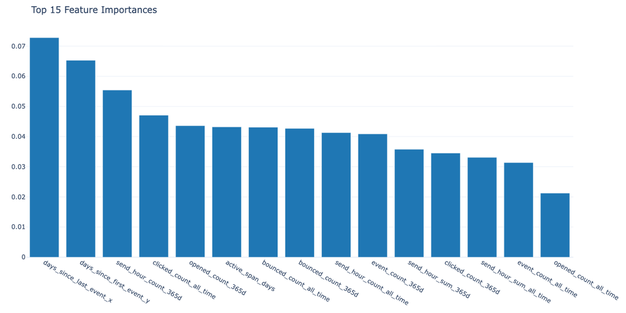

```python
rf_model = models["Random Forest"]
importance_df = pd.DataFrame({
    "Feature": feature_cols,
    "Importance": rf_model.feature_importances_
}).sort_values("Importance", ascending=False)

top_n = 15
top_features = importance_df.head(top_n)

fig = charts.bar_chart(
    top_features["Feature"].tolist(),
    top_features["Importance"].tolist(),
    title=f"Top {top_n} Feature Importances"
)
display_figure(fig)
```

## 8.5 Classification Report (Best Model)

**Show/Hide Code**

```python
best_model = models["Gradient Boosting"]
y_pred = best_model.predict(X_test)

print("Classification Report (Gradient Boosting):")
print(classification_report(y_test, y_pred))
```

```
Classification Report (Gradient Boosting):
              precision    recall  f1-score   support

           0       0.92      0.98      0.95       554
           1       0.98      0.89      0.93       446

    accuracy                           0.94      1000
   macro avg       0.95      0.94      0.94      1000
weighted avg       0.95      0.94      0.94      1000
```

## 8.6 Model Comparison Grid

This visualization shows all models side-by-side with:

- **Row 1**: Confusion matrices (counts and percentages)
- **Row 2**: ROC curves with AUC scores
- **Row 3**: Precision-Recall curves with PR-AUC scores

**📖 How to Read:**

- **Confusion Matrix**: Diagonal = correct predictions. Off-diagonal = errors.
- **ROC Curve**: Higher curve = better. AUC > 0.8 is good, > 0.9 is excellent.
- **PR Curve**: Higher curve = better at finding positives without false alarms.

**Show/Hide Code**

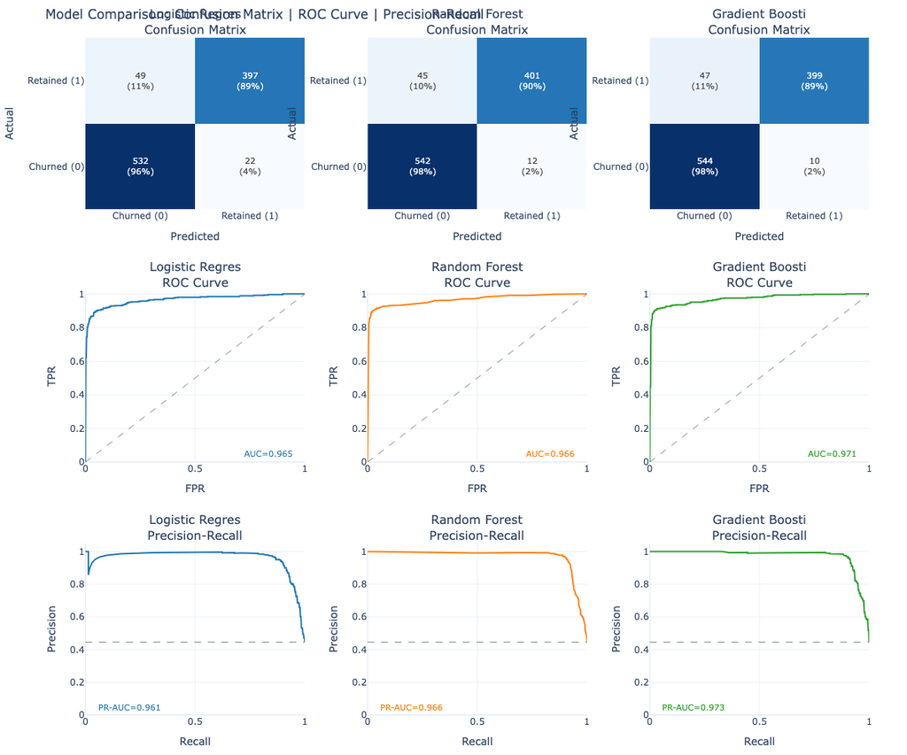

```
================================================================================
METRICS SUMMARY
================================================================================
```

| Model | Test AUC | PR-AUC | F1-Score | Precision | Recall |
| --- | --- | --- | --- | --- | --- |
| Logistic Regression | 0.9646 | 0.9615 | 0.9179 | 0.9475 | 0.8901 |
| Random Forest | 0.9656 | 0.9659 | 0.9336 | 0.9709 | 0.8991 |
| Gradient Boosting | 0.9708 | 0.9726 | 0.9333 | 0.9756 | 0.8946 |

```python
grid_results = {
    name: {"y_pred": data["y_pred"], "y_pred_proba": data["y_pred_proba"]}
    for name, data in model_predictions.items()
}

if _is_binary:
    fig = charts.model_comparison_grid(
        grid_results, y_test,
        class_labels=["Churned (0)", "Retained (1)"],
        title="Model Comparison: Confusion Matrix | ROC Curve | Precision-Recall"
    )
    display_figure(fig)
else:
    import numpy as np
    import plotly.graph_objects as go
    from plotly.subplots import make_subplots
    from sklearn.metrics import confusion_matrix

    model_names = list(grid_results.keys())
    n_models = len(model_names)
    fig = make_subplots(rows=1, cols=n_models, subplot_titles=[f"{n[:20]}" for n in model_names])
    for i, name in enumerate(model_names):
        cm = confusion_matrix(y_test, grid_results[name]["y_pred"])
        fig.add_trace(go.Heatmap(
            z=cm, x=list(range(cm.shape[1])), y=list(range(cm.shape[0])),
            text=cm.astype(str), texttemplate="%{text}", showscale=False,
            colorscale="Blues",
        ), row=1, col=i + 1)
    fig.update_layout(title="Model Comparison: Confusion Matrices (multiclass)", height=400, width=350 * n_models + 50)
    display_figure(fig)

print("\n" + "=" * 80)
print("METRICS SUMMARY")
print("=" * 80)
_metrics_cols = ["Model", "Test AUC", "F1-Score", "Precision", "Recall"]
if _is_binary:
    _metrics_cols.insert(2, "PR-AUC")
display_table(results_df[_metrics_cols])
```

### 8.6.1 Individual Model Analysis

The grid above shows all models together. Below is detailed analysis per model.

**Show/Hide Code**

```python
print("=" * 70)
print("CLASSIFICATION REPORTS BY MODEL")
print("=" * 70)

_target_names = ["Churned", "Retained"] if _is_binary else None

for name, data in model_predictions.items():
    print(f"\n{'='*40}")
    print(f"  {name}")
    print('='*40)
    print(classification_report(y_test, data['y_pred'], target_names=_target_names, zero_division=0))
```

```
======================================================================
CLASSIFICATION REPORTS BY MODEL
======================================================================

========================================
  Logistic Regression
========================================
              precision    recall  f1-score   support

     Churned       0.92      0.96      0.94       554
    Retained       0.95      0.89      0.92       446

    accuracy                           0.93      1000
   macro avg       0.93      0.93      0.93      1000
weighted avg       0.93      0.93      0.93      1000


========================================
  Random Forest
========================================
              precision    recall  f1-score   support

     Churned       0.92      0.98      0.95       554
    Retained       0.97      0.90      0.93       446

    accuracy                           0.94      1000
   macro avg       0.95      0.94      0.94      1000
weighted avg       0.94      0.94      0.94      1000


========================================
  Gradient Boosting
========================================
              precision    recall  f1-score   support

     Churned       0.92      0.98      0.95       554
    Retained       0.98      0.89      0.93       446

    accuracy                           0.94      1000
   macro avg       0.95      0.94      0.94      1000
weighted avg       0.95      0.94      0.94      1000
```

**📖 Why PR Curves for Imbalanced Data:**

**📖 How to Read:**

## 8.7 Key Takeaways

**📖 Interpreting Results:**

**Show/Hide Code**

```python
_primary_metric = "Test AUC" if results_df["Test AUC"].notna().any() else "F1-Score"
best_model = results_df.loc[results_df[_primary_metric].idxmax()]

print("=" * 70)
print("KEY TAKEAWAYS")
print("=" * 70)

print(f"\n  BEST MODEL (by {_primary_metric}): {best_model['Model']}")
if results_df["Test AUC"].notna().any():
    print(f"   Test AUC: {best_model['Test AUC']:.4f}")
if _is_binary:
    print(f"   PR-AUC: {best_model['PR-AUC']:.4f}")
print(f"   F1-Score: {best_model['F1-Score']:.4f}")

print("\n  TOP 3 IMPORTANT FEATURES:")
for i, feat in enumerate(importance_df.head(3)['Feature'].tolist(), 1):
    imp = importance_df[importance_df['Feature'] == feat]['Importance'].values[0]
    print(f"   {i}. {feat} ({imp:.3f})")

_best_score = best_model[_primary_metric]
print("\n  MODEL PERFORMANCE ASSESSMENT:")
if _best_score > 0.90:
    print("   Excellent predictive signal - likely production-ready with tuning")
elif _best_score > 0.80:
    print("   Strong predictive signal - good baseline for improvement")
elif _best_score > 0.70:
    print("   Moderate signal - consider more feature engineering")
else:
    print("   Weak signal - may need more data or different features")

print("\n  NEXT STEPS:")
print("   1. Feature engineering with derived features (notebook 05)")
print("   2. Hyperparameter tuning (GridSearchCV)")
print("   3. Threshold optimization for business metrics")
print("   4. A/B testing in production")
```

```
======================================================================
KEY TAKEAWAYS
======================================================================

  BEST MODEL (by Test AUC): Gradient Boosting
   Test AUC: 0.9708
   PR-AUC: 0.9726
   F1-Score: 0.9333

  TOP 3 IMPORTANT FEATURES:
   1. days_since_last_event_x (0.073)
   2. days_since_first_event_y (0.065)
   3. send_hour_count_365d (0.055)

  MODEL PERFORMANCE ASSESSMENT:
   Excellent predictive signal - likely production-ready with tuning

  NEXT STEPS:
   1. Feature engineering with derived features (notebook 05)
   2. Hyperparameter tuning (GridSearchCV)
   3. Threshold optimization for business metrics
   4. A/B testing in production
```

## Summary: What We Learned

In this notebook, we trained baseline models and established performance benchmarks:

1. **Data Preparation** - Proper train/test split with stratification and scaling
2. **Class Imbalance Handling** - Used balanced class weights
3. **Model Comparison** - Compared Logistic Regression, Random Forest, and Gradient Boosting
4. **Multiple Metrics** - Evaluated with AUC, PR-AUC, F1, Precision, Recall
5. **Feature Importance** - Identified the most predictive features

## Key Results for This Dataset

[output not shown]

## Next Steps

Continue to **09_business_alignment.ipynb** to:

- Align model performance with business objectives
- Define intervention strategies by risk level
- Calculate expected ROI from the model
- Set deployment requirements

**Show/Hide Code**

```python
_best_score_val = results_df[_primary_metric].max()

print("Key Takeaways:")
print("="*50)
print(f"Best baseline {_primary_metric}: {_best_score_val:.4f}")
print(f"Top 3 important features: {', '.join(importance_df.head(3)['Feature'].tolist())}")

if _best_score_val > 0.85:
    print("\nStrong predictive signal detected. Data is well-suited for modeling.")
elif _best_score_val > 0.70:
    print("\nModerate predictive signal. Consider feature engineering for improvement.")
else:
    print("\nWeak predictive signal. May need more features or data.")
```

```
Key Takeaways:
==================================================
Best baseline Test AUC: 0.9708
Top 3 important features: days_since_last_event_x, days_since_first_event_y, send_hour_count_365d

Strong predictive signal detected. Data is well-suited for modeling.
```

## Next Steps

Continue to **09_business_alignment.ipynb** to align with business objectives.

> **Save Reminder:** Save this notebook (Ctrl+S / Cmd+S) before running the next one. The next notebook will automatically export this notebook's HTML documentation from the saved file.